# Odd mix of time varying covariates

Steve Simon

Novemer 18, 2018

Someone asked if you could use the time transfer function to model one time varying covariate while using the start-stop coding to model another time varying covariate. While there is no reason in theory that this wouldn’t work, let’s see what happens in practice.

```r
suppressWarnings(suppressMessages(library(broom)))
suppressWarnings(suppressMessages(library(dplyr)))
suppressWarnings(suppressMessages(library(ggplot2)))
suppressWarnings(suppressMessages(library(magrittr)))
suppressWarnings(suppressMessages(library(survival)))
suppressWarnings(suppressMessages(library(tidyr)))
```

## The Kaplan-Meier plot and proportional hazards.

```r
fn <- "../../data/heroin.txt"
heroin_0 <- read.table(file=fn, skip=1, as.is=TRUE)
v_list <- c(
  "id",
  "clinic",
  "status",
  "time",
  "prison_record",
  "methadone_dose")
names(heroin_0) <- rep(v_list, 2)
head(heroin_0)
```

```
##   id clinic status time prison_record methadone_dose  id clinic status
## 1  1      1      1  428             0             50 132      2      0
## 2  2      1      1  275             1             55 133      2      1
## 3  3      1      1  262             0             55 134      2      1
## 4  4      1      1  183             0             30 135      2      1
## 5  5      1      1  259             1             65 137      2      0
## 6  6      1      1  714             0             55 138      2      0
##   time prison_record methadone_dose
## 1  633             0             70
## 2  661             0             40
## 3  232             1             70
## 4   13             1             60
## 5  563             0             70
## 6  969             0             80
```

```r
heroin <- rbind(heroin_0[ , 1:6], heroin_0[ , 7:12])
heroin$dose_group <- cut(
  heroin$methadone_dose,
  breaks=c(0, 50, 60, 999),
  labels=c("0-50", "51-60", "61+"))
heroin$time_yrs <- heroin$time / 365.25;
table(heroin$methadone_dose, heroin$dose_group)
```

```
##
##       0-50 51-60 61+
##   20     1     0   0
##   30     2     0   0
##   35     2     0   0
##   40    30     0   0
##   45    10     0   0
##   50    27     0   0
##   55     0    21   0
##   60     0    52   0
##   65     0     0  22
##   70     0     0  24
##   75     0     0   6
##   80     0     0  35
##   90     0     0   2
##   100    0     0   3
##   110    0     0   1
```

```r
head(heroin)
```

```
##   id clinic status time prison_record methadone_dose dose_group  time_yrs
## 1  1      1      1  428             0             50       0-50 1.1718001
## 2  2      1      1  275             1             55      51-60 0.7529090
## 3  3      1      1  262             0             55      51-60 0.7173169
## 4  4      1      1  183             0             30       0-50 0.5010267
## 5  5      1      1  259             1             65        61+ 0.7091034
## 6  6      1      1  714             0             55      51-60 1.9548255
```

```r
table(heroin$status)
```

```
##
##   0   1
##  88 150
```

```r
summary(heroin)
```

```
##        id             clinic          status            time
##  Min.   :  1.00   Min.   :1.000   Min.   :0.0000   Min.   :   2.0
##  1st Qu.: 65.25   1st Qu.:1.000   1st Qu.:0.0000   1st Qu.: 171.2
##  Median :131.50   Median :1.000   Median :1.0000   Median : 367.5
##  Mean   :134.13   Mean   :1.315   Mean   :0.6303   Mean   : 402.6
##  3rd Qu.:205.75   3rd Qu.:2.000   3rd Qu.:1.0000   3rd Qu.: 585.5
##  Max.   :266.00   Max.   :2.000   Max.   :1.0000   Max.   :1076.0
##  prison_record    methadone_dose  dose_group    time_yrs
##  Min.   :0.0000   Min.   : 20.0   0-50 :72   Min.   :0.005476
##  1st Qu.:0.0000   1st Qu.: 50.0   51-60:73   1st Qu.:0.468857
##  Median :0.0000   Median : 60.0   61+  :93   Median :1.006160
##  Mean   :0.4664   Mean   : 60.4              Mean   :1.102181
##  3rd Qu.:1.0000   3rd Qu.: 70.0              3rd Qu.:1.603012
##  Max.   :1.0000   Max.   :110.0              Max.   :2.945927
```

Let’s create a new variable to help illustrate the odd mix of time varying covariates in the heroin data set. This is a totally fictional variable, and it is only intended to illustrate a point.

Let’s presume that every patient in the study has the possibility of transitioning from inpatient treatment to outpatient treatment and let’s also suppose that the time of this transition is proportional to the methadone dose. This implies that lower doses make the transition faster.

This implicitly splits the data into two groups. Those who were discharged or censored before they could make the transition to outpatient and those who did make the transition. The latter group has two records, one for time at risk while an inpatient and the other for time at risk while an outpatient.

```r
heroin %>%
  mutate(t_move=runif(238)+methadone_dose/360) -> heroin_1
heroin_1 %>%
  filter(time_yrs > t_move) %>%
  mutate(t0=0) %>%
  mutate(t1=t_move) %>%
  mutate(setting=1) %>%
  mutate(discharge=0) -> move_pre
heroin_1 %>%
  filter(time_yrs >  t_move) %>%
  mutate(t0=t_move) %>%
  mutate(t1=time_yrs) %>%
  mutate(setting=2) %>%
  mutate(discharge=status) -> move_post
heroin_1 %>%
  filter(time_yrs <= t_move) %>%
  mutate(t0=0) %>%
  mutate(t1=time_yrs) %>%
  mutate(setting=1) %>%
  mutate(discharge=status) -> move_none
move_pre %>%
  bind_rows(move_post) %>%
  bind_rows(move_none) %>%
  select(
    id, clinic, t0, t1,
    setting, discharge,
    prison_record) %>%
  arrange(id, t0) -> move_data
head(move_data, 12)
```

```
##    id clinic        t0        t1 setting discharge prison_record
## 1   1      1 0.0000000 0.5679895       1         0             0
## 2   1      1 0.5679895 1.1718001       2         1             0
## 3   2      1 0.0000000 0.7529090       1         1             1
## 4   3      1 0.0000000 0.3740179       1         0             0
## 5   3      1 0.3740179 0.7173169       2         1             0
## 6   4      1 0.0000000 0.5010267       1         1             0
## 7   5      1 0.0000000 0.7091034       1         1             1
## 8   6      1 0.0000000 1.0266064       1         0             0
## 9   6      1 1.0266064 1.9548255       2         1             0
## 10  7      1 0.0000000 1.0585356       1         0             1
## 11  7      1 1.0585356 1.1991786       2         1             1
## 12  8      1 0.0000000 0.7002498       1         0             1
```

```r
table(move_data$setting, move_data$discharge)
```

```
##
##       0   1
##   1 175  63
##   2  67  87
```

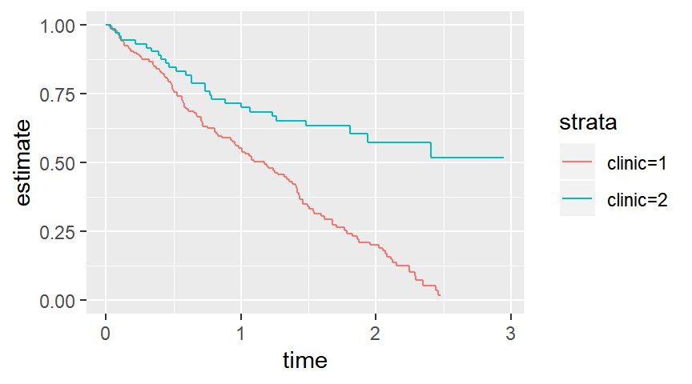

```r
move_data                                   %$%
  Surv(t0, t1, discharge, type="counting")  -> move_surv

move_data                                   %$%
  survfit(move_surv~clinic)                 %>%
  tidy                                      -> km_clinic

km_clinic                                   %>%
  ggplot(aes(time, estimate, color=strata))  +
    expand_limits(y=0)                       +
    geom_step()
```

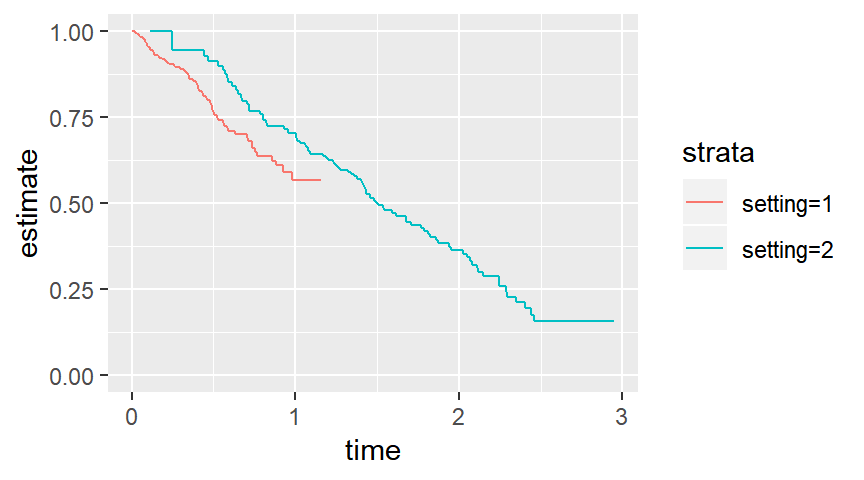

```r
move_data                                   %$%
  survfit(move_surv~setting)                %>%
  tidy                                      -> km_setting

km_setting                                  %>%
  ggplot(aes(time, estimate, color=strata))  +
    expand_limits(y=0)                       +
    geom_step()
```

```r
tt_clinic <- coxph(
  move_surv~
    setting +
    clinic +
    tt(clinic) +
    prison_record,
  tt=function(x, t, ...) x*t,
  data=move_data)
tt_clinic
```

```
## Call:
## coxph(formula = move_surv ~ setting + clinic + tt(clinic) + prison_record,
##     data = move_data, tt = function(x, t, ...) x * t)
##
##                  coef exp(coef) se(coef)     z     p
## setting       -0.2275    0.7965   0.2611 -0.87 0.384
## clinic        -0.0567    0.9449   0.3451 -0.16 0.870
## tt(clinic)    -1.1217    0.3257   0.3416 -3.28 0.001
## prison_record  0.3415    1.4071   0.1674  2.04 0.041
##
## Likelihood ratio test=46.7  on 4 df, p=1.78e-09
## n= 392, number of events= 150
```

```r
save.image("../../data/odd_mix.RData")
```